# Exercise 1

2024-04-24

## Sample Statistics

#### Dataset

Go to UCI Machine learning repository and download the data on the white wine quality. This page contains also the background information on the data. In our analysis we will only consider the following variables:

- volatile.acidity: Volatile acidity
- residual.sugar: Residual sugar
- pH: pH level
- quality: Wine quality in a score between 0 and 10

#### Exercises

1. Read the data into R. Add to the data frame a new binary variable good which is 1 if quality > 5 and 0 otherwise. We would like to compare volatile.acidity and residual.sugar for good and bad wines.

```r
library(tidyverse)
library(here)
library(ggplot2)
library(jmuOutlier)
library(ISLR)
library(glmnet)
library(faraway)
library(JoSAE)
library(lme4)
library(nlme)
library(astsa)
library(maps)
library(mapdata)

white.wine.quality <- read.csv("winequality-white.csv", sep = ";")
white.wine.quality <- white.wine.quality %>% select(volatile.acidity, residual.sugar,
                              pH, quality)

white.wine.quality <- white.wine.quality %>%
  mutate(good = quality > 5)

head(white.wine.quality)
```

```
##   volatile.acidity residual.sugar   pH quality good
## 1             0.27           20.7 3.00       6 TRUE
## 2             0.30            1.6 3.30       6 TRUE
## 3             0.28            6.9 3.26       6 TRUE
## 4             0.23            8.5 3.19       6 TRUE
## 5             0.23            8.5 3.19       6 TRUE
## 6             0.28            6.9 3.26       6 TRUE
```

2. First consider variable residual.sugar.
- Plot histograms of residual.sugar for good and bad wines using different methods available in R to choose the bin width. Comment on the shape of both histograms and differences in distribution, if any.

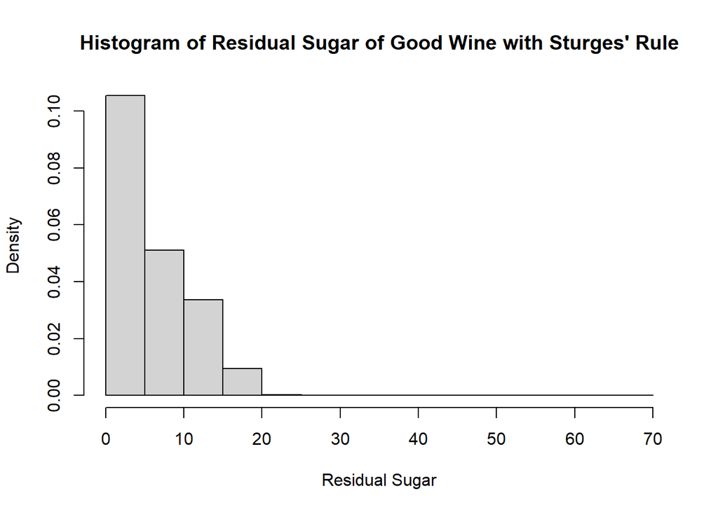

```r
good.wine <- white.wine.quality[white.wine.quality$good == 1,]
bad.wine <- white.wine.quality[white.wine.quality$good == 0,]

hist(good.wine$residual.sugar,
 breaks = "Sturges",
 freq=F,
 main = "Histogram of Residual Sugar of Good Wine with Sturges' Rule",
 xlab = "Residual Sugar")
```

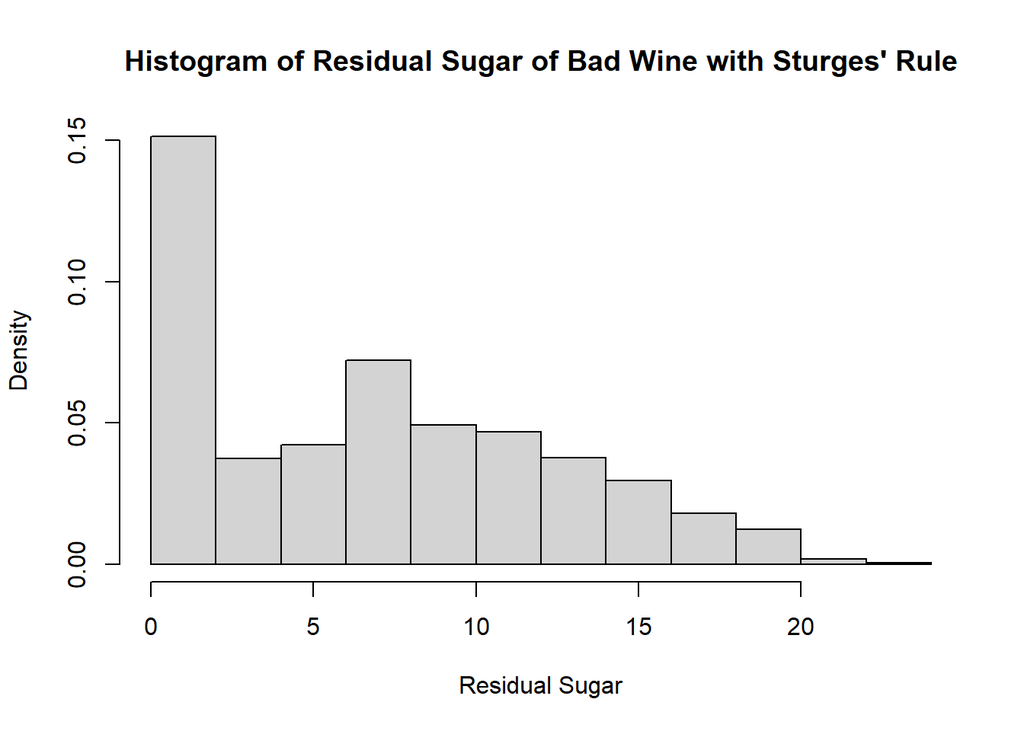

```r
hist(bad.wine$residual.sugar,
 breaks = "Sturges",
 freq=F,
 main = "Histogram of Residual Sugar of Bad Wine with Sturges' Rule",
 xlab = "Residual Sugar")
```

There are 1640 bad wine and 3258 good wine rows. The distribution of good wine seems to have a long tail on the right. The number of bins for good wine is 14 and it is 12 for bad wine when Sturges formula is used.

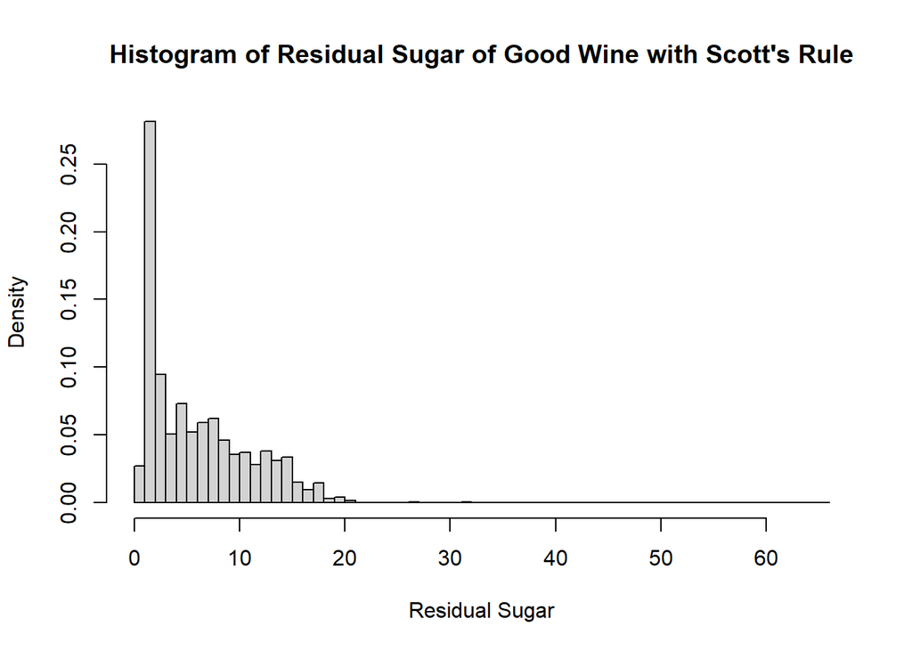

```r
hist(good.wine$residual.sugar,
     breaks = "Scott",
     freq=F,
     main = "Histogram of Residual Sugar of Good Wine with Scott's Rule",
     xlab = "Residual Sugar")
```

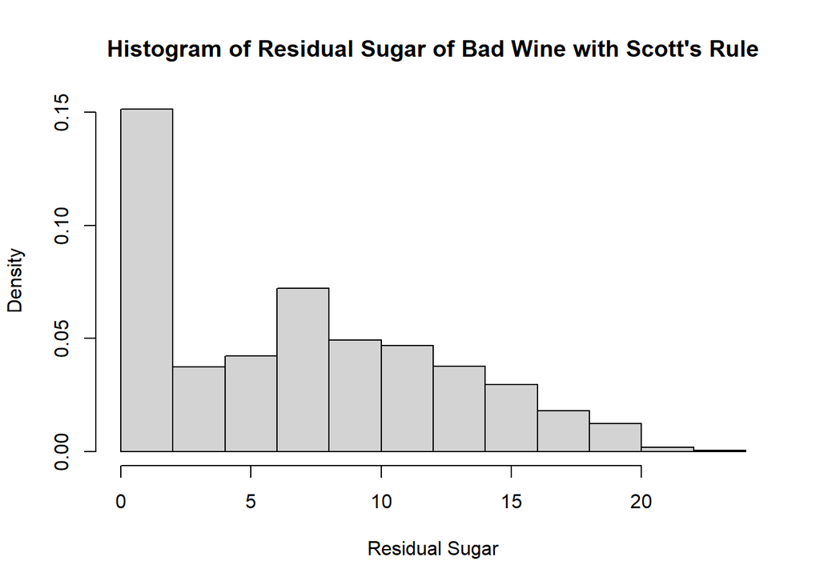

```r
hist(bad.wine$residual.sugar,
     breaks = "Scott",
     freq=F,
     main = "Histogram of Residual Sugar of Bad Wine with Scott's Rule",
     xlab = "Residual Sugar")
```

When Scott’s choice is used, the number of breaks remains the same for the bad wine, but it increases significantly for the good wine. This allows us to capture more information, but it also introduces more noise.

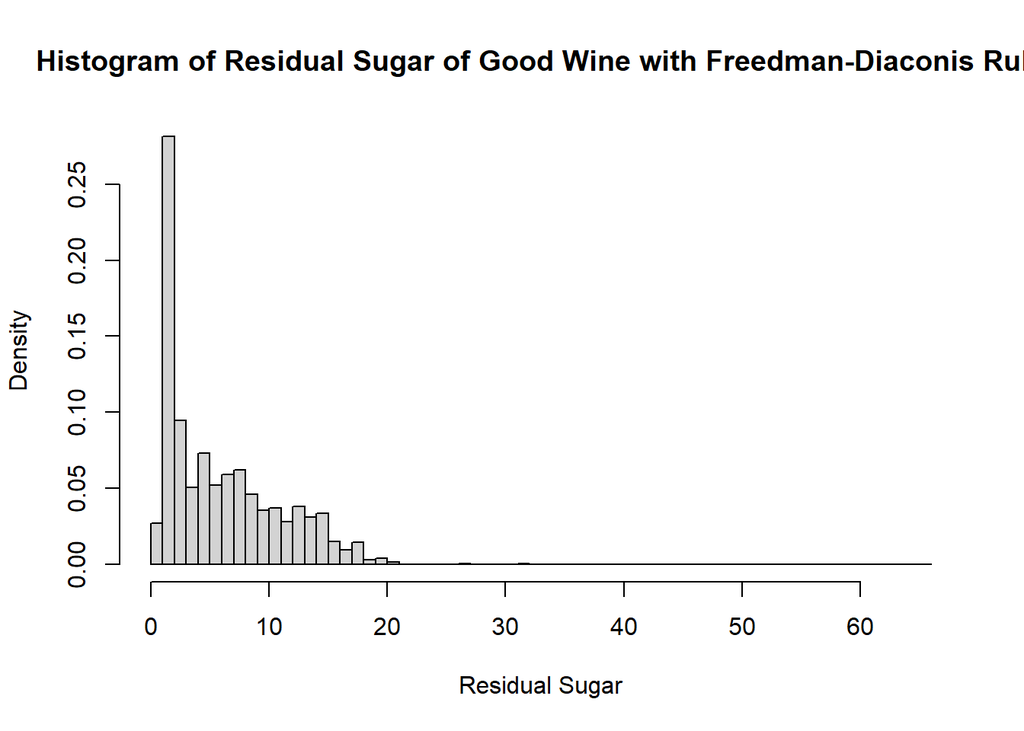

```r
hist(good.wine$residual.sugar,
     breaks = "Freedman-Diaconis",
     freq=F,
     main = "Histogram of Residual Sugar of Good Wine with Freedman-Diaconis Rule",
     xlab = "Residual Sugar")
```

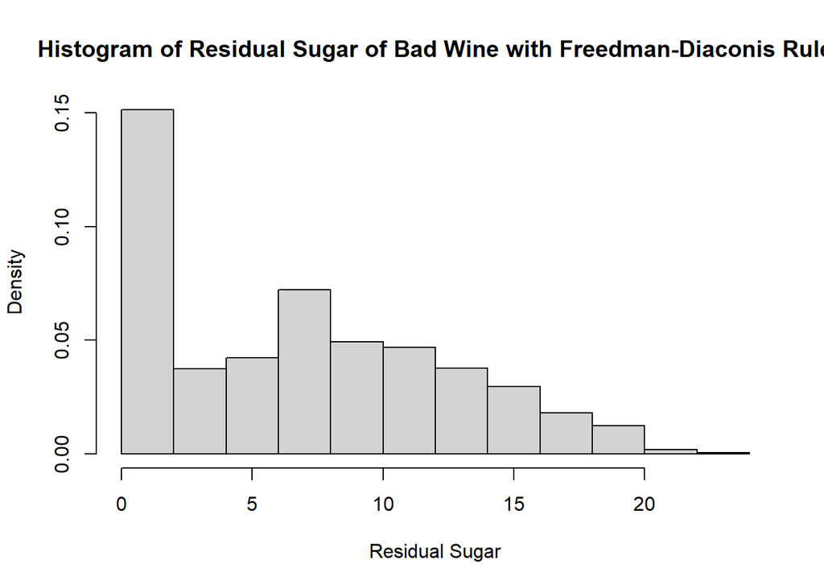

```r
hist(bad.wine$residual.sugar,
     breaks = "Freedman-Diaconis",
     freq=F,
     main = "Histogram of Residual Sugar of Bad Wine with Freedman-Diaconis Rule",
     xlab = "Residual Sugar")
```

When Freedman-Diaconis’ choice is used, the number of breaks is the same as with Scott’s choice. Both Freedman-Diaconis’ and Scott’s choices take variability into account. However, Freedman-Diaconis’ choice utilizes the interquartile range, which can make it more robust to outliers.

- Calculate the summary statistics for both wine groups, that is: mean, median, standard deviation, interquartile range, minimum and maximum of both samples. Display the results in a table and comment on the differences between both groups, if any.

```r
white.wine.quality %>%
  group_by(good) %>%
  summarise(mean.rs = mean(residual.sugar),
                        median.rs = median(residual.sugar),
                        sd.rs = sd(residual.sugar),
                        IQR.rs = IQR(residual.sugar),
                        min.rs = min(residual.sugar),
                        max.rs = max(residual.sugar))
```

```
## # A tibble: 2 × 7
##   good  mean.rs median.rs sd.rs IQR.rs min.rs max.rs
##   <lgl>   <dbl>     <dbl> <dbl>  <dbl>  <dbl>  <dbl>
## 1 FALSE    7.05      6.62  5.28   9.33    0.6   23.5
## 2 TRUE     6.06      4.75  4.93   7.4     0.7   65.8
```

Considering that both of these variables from the good and bad groups are bounded by 0, the maximum values of residual sugar in good wine seem to be very high, possibly indicating an outlier or a high tail on the right side. Despite this high value, the interquartile range (IQR) of good wine is lower than that of bad wine, supporting the fact that the IQR is a variability measure highly robust to outliers.

Despite the presence of the outlier, we can observe that the mean residual sugar of bad wine is higher than that of good wine. The median also appears to be considerably higher. However, the question arises whether these differences are statistically significant.

- Generate boxplots for both samples, placing them into one graphic. What do you observe?

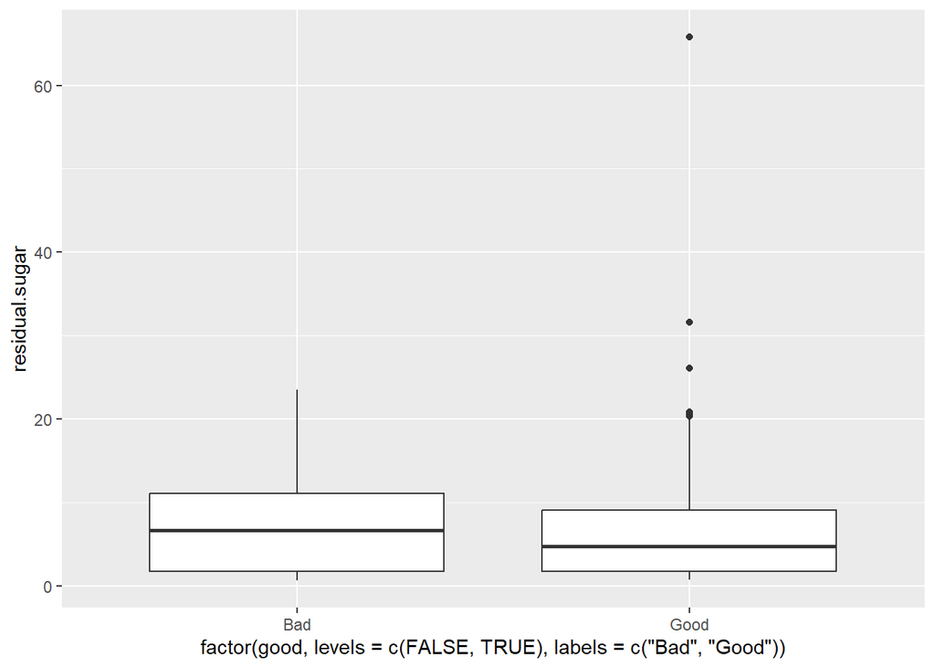

```r
p <- ggplot(white.wine.quality, aes(factor(good, levels = c(FALSE, TRUE), labels = c("Bad", "Good")), residual.sugar))
p + geom_boxplot()
```

We can support the pattern we encountered in the previous question. It is highly likely that the value 65.8 is an outlier. There are a couple more values above the upper whisker. The median of the bad wine group is slightly higher than that of the good wine group.

- Generate a QQ-plot to compare two groups. Make sure to choose the same range for both axes. Add a y = x line to the plots. Comment on the results.

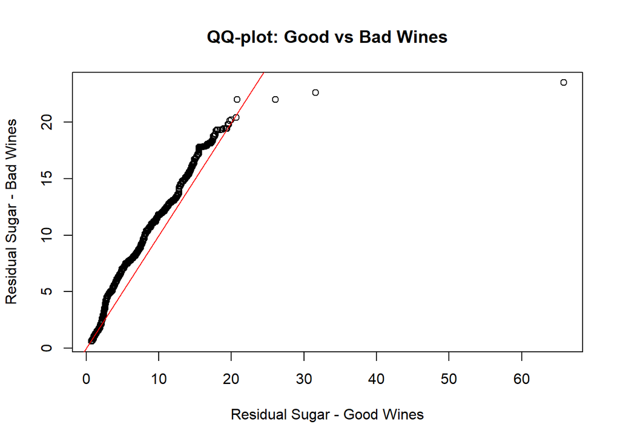

```r
qqplot(good.wine$residual.sugar, bad.wine$residual.sugar, main = "QQ-plot: Good vs Bad Wines",
       xlab = "Residual Sugar - Good Wines", ylab = "Residual Sugar - Bad Wines")
abline(0, 1, col = "red")  # Add y = x line
```

We can observe that the residual sugar distribution of good wine is more right-skewed than that of bad wine. Additionally, we can identify those extreme values in the distribution of good wines.

- Plot the empirical distribution functions of both groups in one graphic. Use different styles and add a legend. Interpret the results.

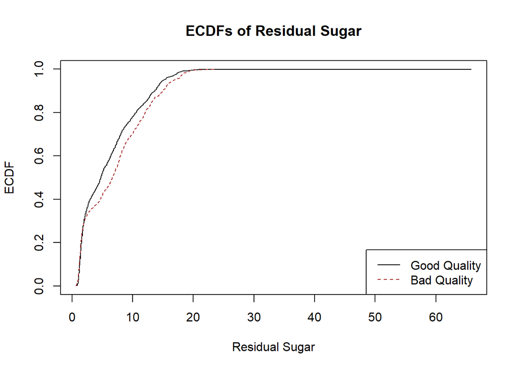

```r
ecdf.func <- function(data) {
  Length <- length(data)
  sorted <- sort(data)

  ecdf <- rep(0, Length)
  for (i in 1:Length) {
    ecdf[i] <- sum(sorted <= sorted[i]) / Length
  }
  return(list(sorted = sorted, ecdf = ecdf))
}

# Calculate ECDFs for good and bad wine residual sugar
ecdf.good.rs <- ecdf.func(good.wine$residual.sugar)
ecdf.bad.rs <- ecdf.func(bad.wine$residual.sugar)

# Plot ECDF for good wine
plot(ecdf.good.rs$sorted, ecdf.good.rs$ecdf, type = "s", main = "ECDFs of Residual Sugar", xlab = "Residual Sugar", ylab = "ECDF", col = "black", lty = 1)

# Add ECDF for bad wine
lines(ecdf.bad.rs$sorted, ecdf.bad.rs$ecdf, type = "s", col = "brown", lty = 2)

# Add legend
legend("bottomright", legend = c("Good Quality", "Bad Quality"), col = c("black", "brown"), lty = c(1, 2))
```

Here the definition of ECDF is important. I will simply use the one in the lecture in the rest of the report. While the brown plot represents the ECDF of residual sugar for bad wine, the black one represents that of good wine. From the ECDF, we can identify where the most values occur. It’s evident that there are more values of lower residual sugar for good wine than for bad wine. However, up to a certain point, we can say they distribute similarly. Afterwards, bad quality wines usually have more sugar.

3. Consider now volatile.acidity for good and bad wines. Use boxplots, histograms, QQplots, summary statistics and empirical distribution functions to compare this variable for good and bad wines. Comment on the results.

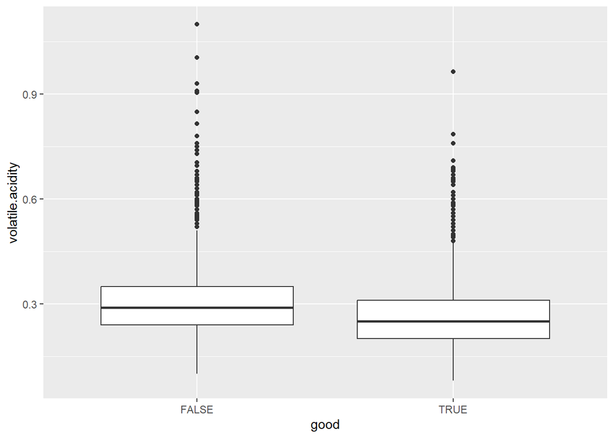

```r
p <- ggplot(white.wine.quality, aes(good, volatile.acidity))
p + geom_boxplot()
```

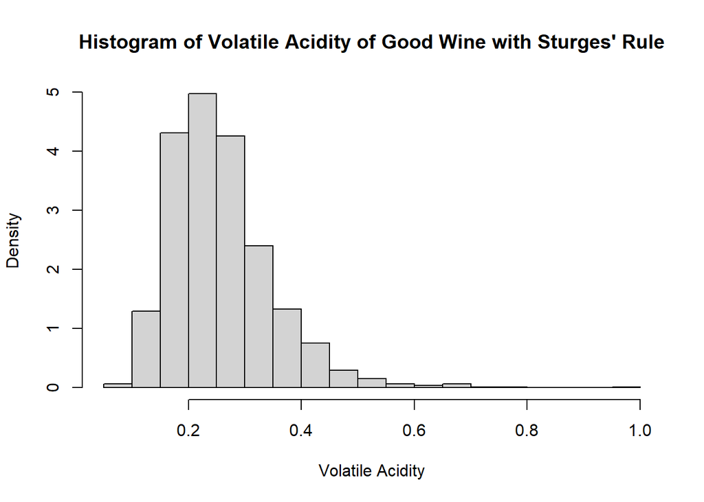

```r
hist(good.wine$volatile.acidity,
 breaks = "Sturges",
 freq=F,
 main = "Histogram of Volatile Acidity of Good Wine with Sturges' Rule",
 xlab = "Volatile Acidity")
```

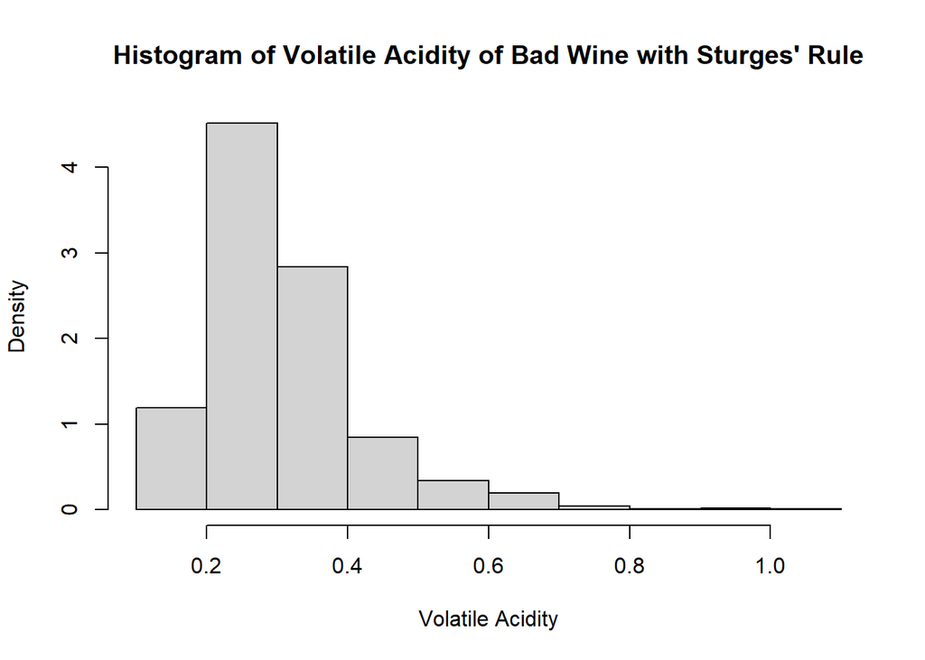

```r
hist(bad.wine$volatile.acidity,
 breaks = "Sturges",
 freq=F,
 main = "Histogram of Volatile Acidity of Bad Wine with Sturges' Rule",
 xlab = "Volatile Acidity")
```

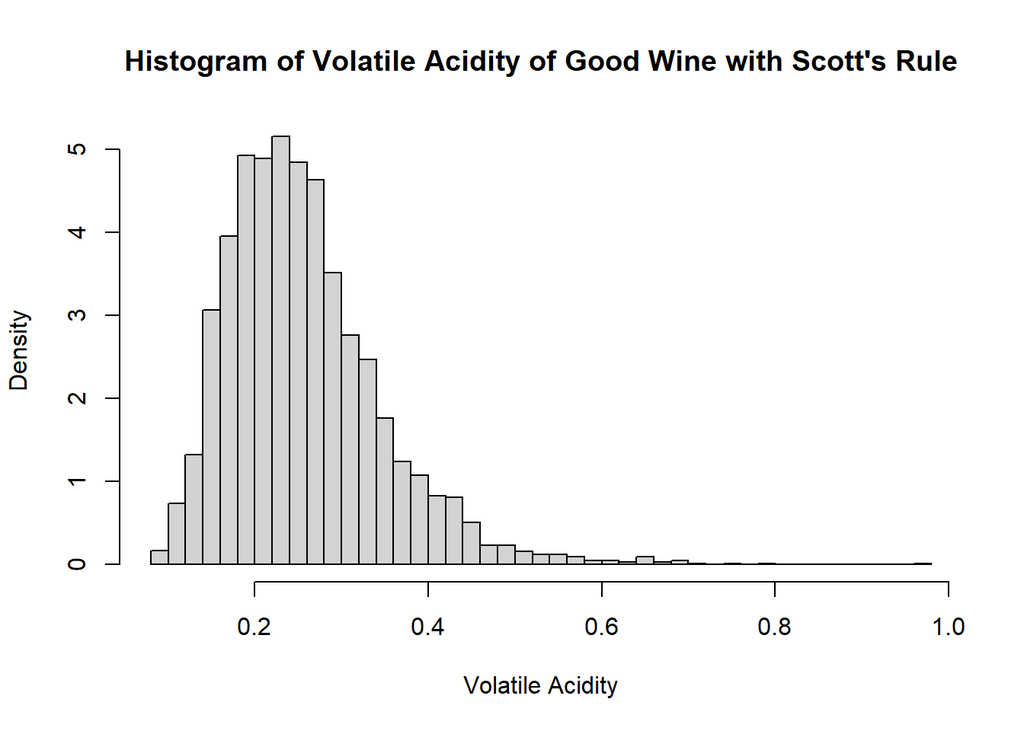

```r
hist(good.wine$volatile.acidity,
     breaks = "Scott",
     freq=F,
     main = "Histogram of Volatile Acidity of Good Wine with Scott's Rule",
     xlab = "Volatile Acidity")
```

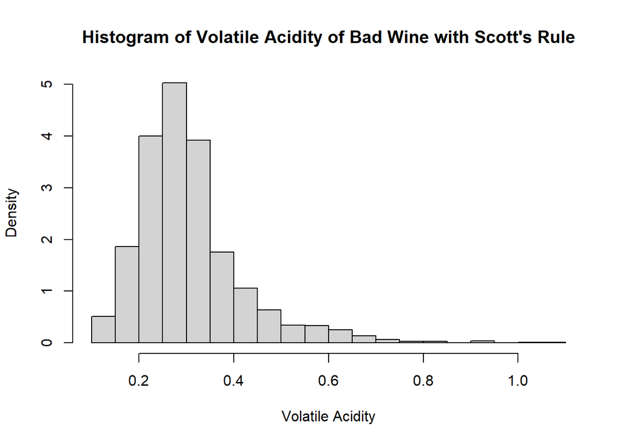

```r
hist(bad.wine$volatile.acidity,
     breaks = "Scott",
     freq=F,
     main = "Histogram of Volatile Acidity of Bad Wine with Scott's Rule",
     xlab = "Volatile Acidity")
```

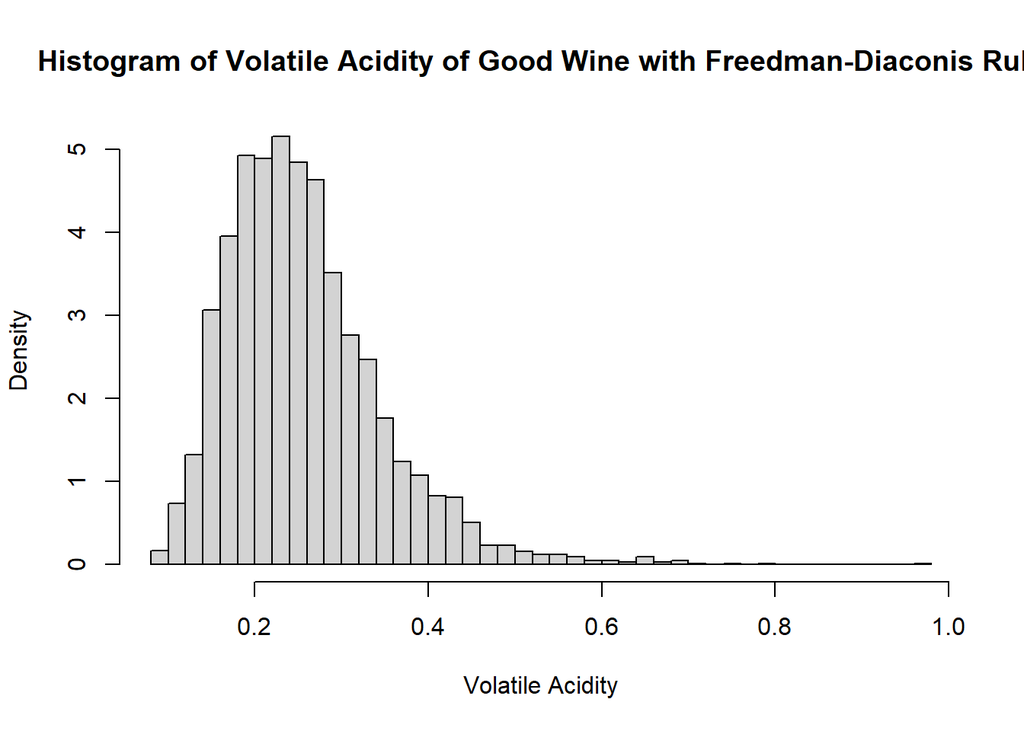

```r
hist(good.wine$volatile.acidity,
     breaks = "Freedman-Diaconis",
     freq=F,
     main = "Histogram of Volatile Acidity of Good Wine with Freedman-Diaconis Rule",
     xlab = "Volatile Acidity")
```

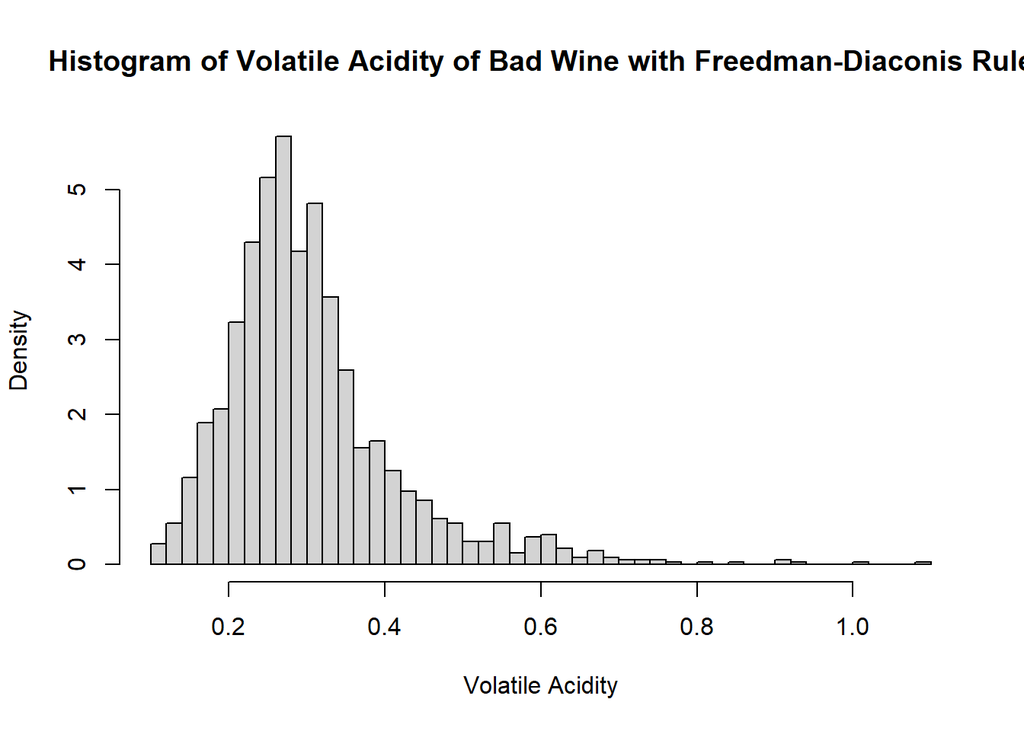

```r
hist(bad.wine$volatile.acidity,
     breaks = "Freedman-Diaconis",
     freq=F,
     main = "Histogram of Volatile Acidity of Bad Wine with Freedman-Diaconis Rule",
     xlab = "Volatile Acidity")
```

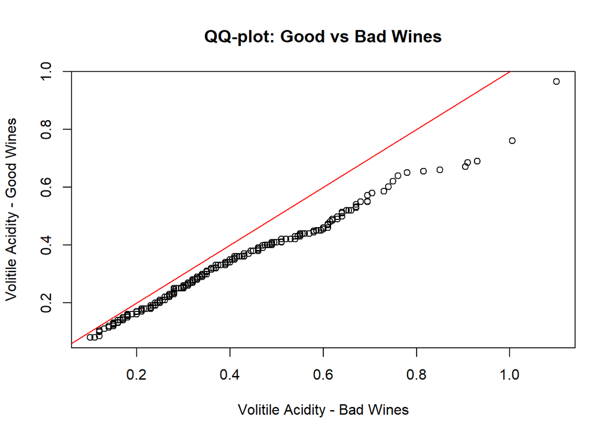

```r
qqplot(bad.wine$volatile.acidity, good.wine$volatile.acidity, main = "QQ-plot: Good vs Bad Wines",
       xlab = "Volitile Acidity - Bad Wines", ylab = "Volitile Acidity - Good Wines")
abline(0, 1, col = "red")  # Add y = x line
```

```r
white.wine.quality %>%
  group_by(good) %>%
  summarise(mean.va = mean(volatile.acidity),
                        median.va = median(volatile.acidity),
                        sd.va = sd(volatile.acidity),
                        IQR.va = IQR(volatile.acidity),
                        min.va = min(volatile.acidity),
                        max.va = max(volatile.acidity))
```

```
## # A tibble: 2 × 7
##   good  mean.va median.va  sd.va IQR.va min.va max.va
##   <lgl>   <dbl>     <dbl>  <dbl>  <dbl>  <dbl>  <dbl>
## 1 FALSE   0.310      0.29 0.113    0.11   0.1   1.1
## 2 TRUE    0.262      0.25 0.0901   0.11   0.08  0.965
```

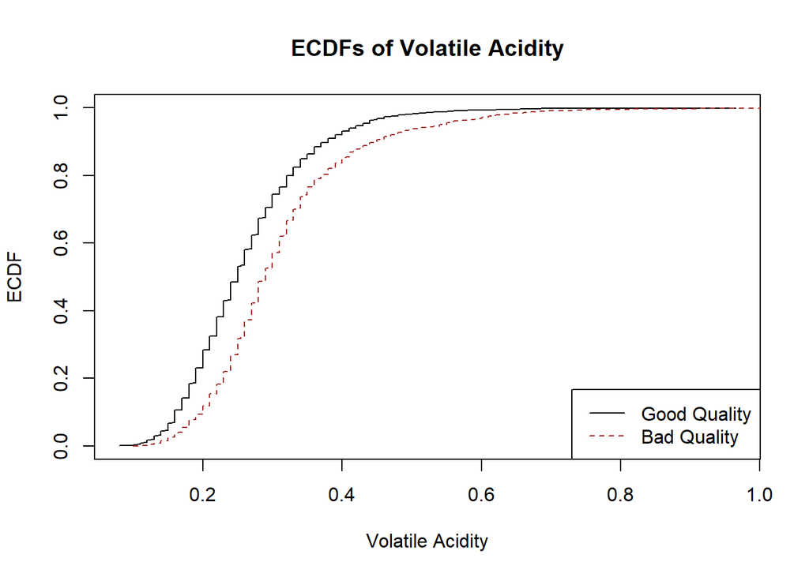

```r
ecdf.good.va <- ecdf.func(good.wine$volatile.acidity)
ecdf.bad.va <- ecdf.func(bad.wine$volatile.acidity)

# Plot ECDF for good wine
plot(ecdf.good.va$sorted, ecdf.good.va$ecdf, type = "s", main = "ECDFs of Volatile Acidity", xlab = "Volatile Acidity", ylab = "ECDF", col = "black", lty = 1)

# Add ECDF for bad wine
lines(ecdf.bad.va$sorted, ecdf.bad.va$ecdf, type = "s", col = "brown", lty = 2)

# Add legend
legend("bottomright", legend = c("Good Quality", "Bad Quality"), col = c("black", "brown"), lty = c(1, 2))
```

Boxplots of both wine groups seem to have a very heavy and long right tail. The median of the bad wine group is slightly higher than that of the good wine group.

When we look at histograms, transitioning from Sturges’ Rule to Scott’s Rule, the number of bins increases for both good and bad wines. The reason why it did not differ in residual sugar might be that the variance in volatile acidity is much lower than the variance in residual sugar. Additionally, the IQR of volatile acidity is significantly lower than that of residual sugar in both wines. Eventually, the bin width of Freedman-Diaconis is very small in bad wines as well.

Looking at the QQ plot, we can see that the values of good wine are more concentrated or have less variance than those for bad wines because of the slope of the QQ plot. Additionally since values are below the y=x line, the good wine group is expected to have lower mean.